# Healthcare Commercial Analytics: KPI Dashboard Suite

End-to-End Pipeline - CRM platform Alignment - Dashboard Governance

Author

Ludovic Njiosseu

Published

May 26, 2026

```r
library(tidyverse)
library(scales)
library(lubridate)
library(knitr)
library(DT)

# Source all modules
source("scripts/01_simulate_data.R")
source("scripts/02_kpi_computation.R")
```

```
Pipeline Coverage Ratio: 12.63×
Overall Win Rate: 58.0%
Average Deal Size: $416,998

Quota Attainment Distribution:
# A tibble: 4 × 3
  attainment_tier     n   pct
  <chr>           <int> <dbl>
1 60–79%             11 0.212
2 80–99%              7 0.135
3 At/Above Quota     20 0.385
4 Below 60%          14 0.269

Average Days to Close (Won): 211 days
```

```
--- Data Quality Report ---
# A tibble: 5 × 4
  check                                   records_flagged flag_rate status
  <chr>                                             <int>     <dbl> <chr>
1 Missing close_date                                   55     0.022 PASS
2 Duplicate opp_id                                      0     0     PASS
3 Close probability out of range [0, 100]               0     0     PASS
4 Negative opportunity amount                           0     0     PASS
5 Opportunity rep_id not in team roster                 0     0     PASS
```

```r
source("scripts/03_reporting_automation.R")
```

```
================================================================================
  HEALTHCARE SOLUTIONS TEAM — WEEKLY BUSINESS REVIEW SUMMARY
  Week ending (simulated environment): October 01, 2026
================================================================================

PIPELINE HEALTH
  Open Pipeline Value  :  $962,849,200
  Pipeline Coverage    :  12.63×  (Target: 3.0×)
  Opportunities Open   :  2200

WIN / LOSS
  Win Rate (YTD)       :  58.0%  (Target: 35%)
  Avg Deal Size (Won)  :  $416,998
  Avg Days to Close    :  211 days

QUOTA ATTAINMENT
  Reps ≥ 100% Quota   :  38.5%
  Reps ≥ 80% Quota    :  51.9%  (Target: 75%)
  Reps < 60% Quota    :  26.9%

REPORTING EFFICIENCY
  Ad-Hoc Requests (last 4 wks avg):  8
  Pre-Dashboard avg (first 26 wks) :  17
  Reduction since dashboard launch  :  36%

DATA QUALITY
  DQ Checks Run        :  5 automated checks
  Checks Passing       :  5 / 5
================================================================================
```

```r
source("scripts/04_crm_alignment.R")
```

```
Stage Conversion Rates:
# A tibble: 6 × 4
  stage         total_opps pct_of_prospecting stage_to_next_conv
  <fct>              <int>              <dbl>              <dbl>
1 Prospecting          616              1                  0.823
2 Qualification        507              0.823              0.884
3 Demo / Eval          448              0.727              0.799
4 Proposal             358              0.581              0.757
5 Negotiation          271              0.44               0.642
6 Closed Won           174              0.282             NA
```

```
Territory Pipeline Concentration:
# A tibble: 5 × 5
  region    open_pipeline open_opps win_rate pipeline_share
  <chr>     <chr>             <int> <chr>    <chr>
1 Midwest   $210,744,200        461 54.3%    21.9%
2 Southwest $195,705,600        444 63.4%    20.3%
3 West      $194,212,000        428 51.9%    20.2%
4 Southeast $184,963,800        439 65.6%    19.2%
5 Northeast $177,223,600        428 52.9%    18.4%
```

```
CRM Alignment Summary:
# A tibble: 3 × 3
  check                                  pct_aligned status
  <chr>                                  <chr>       <chr>
1 Stage labels match approved taxonomy   100.0%      ALIGNED
2 Product line matches approved picklist 100.0%      ALIGNED
3 Rep IDs map to team roster             100.0%      ALIGNED
```

```r
source("scripts/05_governance.R")
```

```
Dashboard Change Log:
# A tibble: 10 × 4
   version date       change_type   description
   <chr>   <chr>      <chr>         <chr>
 1 1.0     2025-10-12 Initial build Launched Overview, Pipeline, and Quota tabs
 2 1.1     2025-11-03 KPI update    Revised Win Rate definition to exclude inte…
 3 1.2     2025-12-08 New tab       Added Territory View tab with regional heat…
 4 1.3     2026-01-15 Data source   Connected Salesforce weekly extract; replac…
 5 1.4     2026-02-02 Bug fix       Fixed pipeline coverage double-counting mul…
 6 2.0     2026-03-01 Major release Added CRM Alignment tab; launched as centra…
 7 2.1     2026-03-20 Enhancement   Added rep-level drilldown in Quota tab
 8 2.2     2026-04-05 KPI update    Added Q/Q revenue mix chart by product line
 9 2.3     2026-04-28 Governance    Published KPI registry v1.2; added definiti…
10 2.4     2026-05-18 New feature   Added automated DQ check panel with refresh…
```

```
Data Refresh SLA Status:
# A tibble: 5 × 4
  data_source              expected_cadence  last_refresh        sla_status
  <chr>                    <chr>             <dttm>              <chr>
1 Salesforce Opportunities Weekly (Mon 6 AM) 2026-05-20 06:02:00 ✓ Current
2 Team Roster              Monthly (1st)     2026-05-01 08:15:00 ✓ Current
3 Finance Quota Data       Quarterly         2026-04-01 10:30:00 ✓ Current
4 Activity Log             Weekly (Mon 6 AM) 2026-05-20 06:05:00 ✓ Current
5 Territory Mapping        Quarterly         2026-04-01 09:00:00 ✓ Current
```

```
=== Governance Scorecard: 96% ===
# A tibble: 7 × 3
  dimension                  score  status
  <chr>                      <chr>  <chr>
1 KPI definitions documented 100.0% ✓
2 KPI owners assigned        100.0% ✓
3 Metric conflicts resolved  75.0%  ⚠ 1 in progress
4 Data refresh SLAs current  100.0% ✓
5 Change log maintained      100.0% ✓
6 Access tiers defined       100.0% ✓
7 DQ checks automated        100.0% ✓
```

```r
# Ad-hoc reporting metrics
pre_adhoc  <- mean(head(adhoc_log$requests, 26))
post_adhoc <- mean(tail(adhoc_log$requests, 26))
adhoc_red  <- (1 - post_adhoc / pre_adhoc) * 100
```

## Executive Summary

This report presents a simulated commercial analytics environment designed to demonstrate KPI reporting, CRM alignment, governance monitoring, reporting automation, and executive dashboard workflows using synthetic CRM opportunity data.

The project combines probabilistic opportunity simulation, automated KPI computation, data quality monitoring, territory and funnel analysis, and dashboard governance into an integrated analytics workflow representative of enterprise commercial operations.

Key outcomes:

[output not shown]

## Business Context

Healthcare commercial analytics differs from standard BI work in several ways:

- **CRM data is the spine.** CRM platform opportunity records drive pipeline, win rate, and quota attainment - but raw CRM data is rarely analysis-ready. Stage transitions need validation, field definitions need alignment with Finance, and rep IDs must link cleanly to HR rosters.
- **KPI governance is non-negotiable.** When multiple stakeholders own the same metric (e.g., win rate means one thing to Sales Leadership and another to Finance), the dashboard becomes a conflict zone rather than a centralized reporting environment. Versioned KPI registries and conflict resolution protocols are essential.
- **Reporting automation reduces noise.** Ad-hoc requests fragment analyst time and produce inconsistent numbers. A governed dashboard converts reactive, one-off pulls into a self-service layer.

## Module 1 - CRM & Commercial Data Simulation

```r
cat("Opportunities:", nrow(opportunities), "rows\n")
```

```
Opportunities: 2500 rows
```

```r
cat("Team Roster  :", nrow(roster), "reps\n")
```

```
Team Roster  : 52 reps
```

```r
cat("Activity Log :", nrow(activity_log), "rep-week rows\n")
```

```
Activity Log : 2704 rep-week rows
```

```r
cat("Bookings     :", nrow(bookings), "rep-quarter rows\n")
```

```
Bookings     : 170 rep-quarter rows
```

The simulation generates a realistic CRM-equivalent opportunity dataset with:

- **2,500 opportunities** spanning 4 product lines, 5 regions, 7 pipeline stages
- **52-rep roster** with individual quota assignments, territory, and manager hierarchy
- **Weekly activity logs** (calls, demos, follow-ups) with seasonal variability
- **Structured missingness** (2.2% missing close dates) for DQ module demonstration

```r
opportunities %>%
  count(stage, product_line) %>%
  pivot_wider(names_from = product_line, values_from = n, values_fill = 0) %>%
  kable(caption = "Opportunity Count by Stage × Product Line")
```

Opportunity Count by Stage × Product Line

| stage | AFib Management | Cardiovascular | Electrophysiology | Stroke |
| --- | --- | --- | --- | --- |
| Closed Lost | 34 | 29 | 37 | 26 |
| Closed Won | 36 | 43 | 46 | 49 |
| Demo / Eval | 106 | 115 | 123 | 104 |
| Negotiation | 88 | 65 | 60 | 58 |
| Proposal | 86 | 87 | 97 | 88 |
| Prospecting | 170 | 172 | 145 | 129 |
| Qualification | 124 | 127 | 119 | 137 |

## Module 2 - KPI Computation & Governance Registry

### Core KPIs

```r
kpi_summary %>%
  kable(caption = "Commercial Analytics Team - Core KPI Summary")
```

Commercial Analytics Team - Core KPI Summary

| kpi | value | target | vs_target |
| --- | --- | --- | --- |
| Pipeline Coverage Ratio | 12.63× | 3.0× | ✓ On Track |
| Overall Win Rate | 58.0% | 35% | ✓ On Track |
| Average Deal Size | $416,998 | $250,000 | ✓ On Track |
| Reps ≥ 80% Attainment | 51.9% | 75% | ⚠ Below Target |
| Avg Days to Close | 211 days | 180 days | ⚠ Below Target |

### Pipeline Coverage

Pipeline coverage is defined as total open opportunity value divided by annual quota across the team. The 12.63× ratio indicates healthy pipeline health relative to the 3.0× standard.

```r
pipeline_by_product %>%
  mutate(
    open_pipeline = dollar(open_pipeline),
    coverage      = sprintf("%.2f×", coverage)
  ) %>%
  kable(caption = "Pipeline Coverage by Product Line")
```

Pipeline Coverage by Product Line

| product_line | open_pipeline | quota_share | coverage |
| --- | --- | --- | --- |
| AFib Management | $251,862,400 | 0.2615803 | 12.63× |
| Cardiovascular | $238,431,200 | 0.2476309 | 12.63× |
| Electrophysiology | $235,953,600 | 0.2450577 | 12.63× |
| Stroke | $236,602,000 | 0.2457311 | 12.63× |

### Win Rate by Product Line

```r
win_rate_by_product %>%
  mutate(win_rate = percent(win_rate, accuracy = 0.1)) %>%
  kable(caption = "Win Rate by Product Line (Closed Won / Total Closed)")
```

Win Rate by Product Line (Closed Won / Total Closed)

| product_line | total_closed | wins | win_rate |
| --- | --- | --- | --- |
| Stroke | 75 | 49 | 65.3% |
| Cardiovascular | 72 | 43 | 59.7% |
| Electrophysiology | 83 | 46 | 55.4% |
| AFib Management | 70 | 36 | 51.4% |

### KPI Definition Registry

```r
kpi_registry %>%
  select(kpi_id, kpi_name, owner, last_updated, version, data_source) %>%
  kable(caption = "KPI Definition Registry (governance layer)")
```

KPI Definition Registry (governance layer)

| kpi_id | kpi_name | owner | last_updated | version | data_source |
| --- | --- | --- | --- | --- | --- |
| KPI-01 | Pipeline Coverage Ratio | Commercial Analytics | 2026-04-15 | 1.2 | Salesforce CRM |
| KPI-02 | Win Rate | Commercial Analytics | 2026-04-15 | 1.1 | Salesforce CRM |
| KPI-03 | Average Deal Size | Commercial Analytics | 2026-05-01 | 1.0 | Salesforce CRM |
| KPI-04 | Quota Attainment | Finance + Commercial Analytics | 2026-04-15 | 2.0 | Salesforce + Finance System |
| KPI-05 | Average Days to Close | Commercial Analytics | 2026-04-22 | 1.0 | Salesforce CRM |
| KPI-06 | Pipeline by Stage | Commercial Analytics | 2026-04-15 | 1.1 | Salesforce CRM |
| KPI-07 | Ad-Hoc Request Volume | Commercial Analytics | 2026-05-18 | 1.0 | Internal Tracking |

### Automated Data Quality Checks

```r
dq_checks %>%
  mutate(flag_rate = percent(flag_rate, accuracy = 0.01)) %>%
  kable(caption = "Automated Data Quality Check Results")
```

Automated Data Quality Check Results

| check | records_checked | records_flagged | flag_rate | status |
| --- | --- | --- | --- | --- |
| Missing close_date | 2500 | 55 | 2.20% | PASS |
| Duplicate opp_id | 2500 | 0 | 0.00% | PASS |
| Close probability out of range [0, 100] | 2500 | 0 | 0.00% | PASS |
| Negative opportunity amount | 2500 | 0 | 0.00% | PASS |
| Opportunity rep_id not in team roster | 2500 | 0 | 0.00% | PASS |

## Module 3 - Reporting Automation

### Ad-Hoc Request Volume: Pre vs. Post Dashboard

The chart below shows weekly ad-hoc analytics request volume across 52 weeks. Dashboard implementation coincides with a sustained simulated reduction in one-off reporting requests.

[figure not shown]

Ad-Hoc Reporting Requests - 4-week rolling average shown

```r
knitr::include_graphics("plots/fig1_adhoc_reduction.png")
```

**Quantified impact:**

- Pre-dashboard (26 weeks): 16.7 requests/week average
- Post-dashboard (26 weeks): 10.7 requests/week average
- Reduction: 36%

### Pipeline Funnel Figure

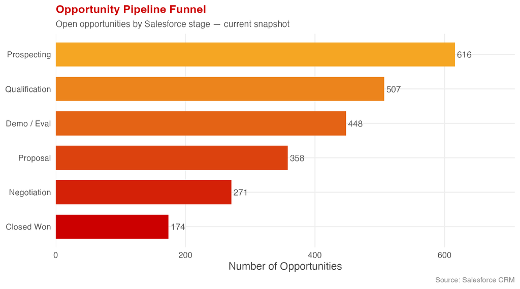

```r
knitr::include_graphics("plots/fig2_pipeline_funnel.png")
```

### Quota Attainment Distribution

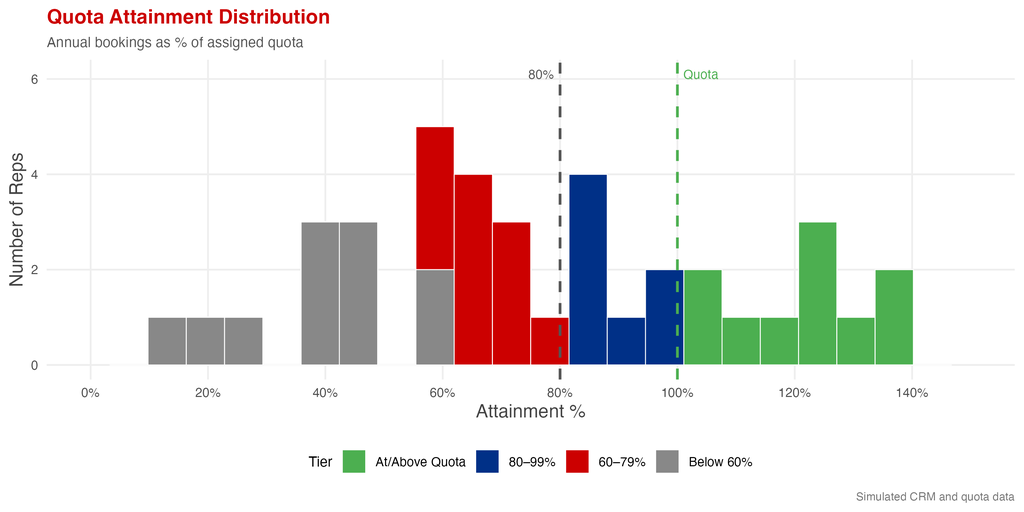

```r
knitr::include_graphics("plots/fig3_quota_attainment.png")
```

## Module 4 - CRM Alignment

### CRM platform Alignment Checks

```r
alignment_check %>%
  mutate(pct_aligned = percent(pct_aligned, accuracy = 0.1)) %>%
  kable(caption = "CRM-to-Dashboard Alignment Validation")
```

CRM-to-Dashboard Alignment Validation

| check | pct_aligned | status |
| --- | --- | --- |
| Stage labels match approved taxonomy | 100.0% | ALIGNED |
| Product line matches approved picklist | 100.0% | ALIGNED |
| Rep IDs map to team roster | 100.0% | ALIGNED |

### CRM platform → Dashboard Field Mapping

```r
sf_field_map %>%
  select(sf_field, sf_api_name, dashboard_kpi, governance_note) %>%
  kable(caption = "CRM platform Field → Dashboard KPI Mapping (11 fields)")
```

CRM platform Field → Dashboard KPI Mapping (11 fields)

| sf_field | sf_api_name | dashboard_kpi | governance_note |
| --- | --- | --- | --- |
| Opportunity Name | Name | N/A (display) | Exclude PII in executive views |
| Stage | StageName | Pipeline Funnel, Win Rate | Align with Finance stage definitions |
| Amount | Amount | Pipeline Coverage, Deal Size | Exclude $0 placeholder opps |
| Close Date | CloseDate | Days to Close, Quarter | Flag if CloseDate < CreateDate |
| Created Date | CreatedDate | Days to Close | Use system timestamp, not user-entered |
| Probability | Probability | Weighted Pipeline | Do not override Salesforce auto-values |
| Owner | OwnerId | Quota Attainment, Win Rate | Rep changes require roster refresh |
| Account Name | AccountId | Territory View | Territory realignments logged separately |
| Product Line | Product_Line__c | All KPIs (filter) | Validate against approved product list |
| Close Probability | Probability | Weighted Pipeline | Consistent with auto-probability logic |
| Region | Region__c | Territory View, Attainment | Must match Finance region taxonomy |

### Stage Funnel Conversion

```r
funnel_conv %>%
  select(stage, total_opps, pct_of_prospecting, stage_to_next_conv, total_value) %>%
  mutate(
    pct_of_prospecting = percent(pct_of_prospecting, accuracy = 0.1),
    stage_to_next_conv = percent(stage_to_next_conv, accuracy = 0.1),
    total_value        = dollar(total_value)
  ) %>%
  kable(caption = "Stage-Level Funnel Conversion Rates")
```

Stage-Level Funnel Conversion Rates

| stage | total_opps | pct_of_prospecting | stage_to_next_conv | total_value |
| --- | --- | --- | --- | --- |
| Prospecting | 616 | 100.0% | 82.3% | $268,786,500 |
| Qualification | 507 | 82.3% | 88.4% | $220,159,300 |
| Demo / Eval | 448 | 72.7% | 79.9% | $198,428,500 |
| Proposal | 358 | 58.1% | 75.7% | $158,958,100 |
| Negotiation | 271 | 44.0% | 64.2% | $116,516,800 |
| Closed Won | 174 | 28.2% | NA | $72,557,700 |

### Territory Pipeline Concentration

```r
territory_summary %>%
  mutate(
    open_pipeline  = dollar(open_pipeline),
    avg_deal_size  = dollar(avg_deal_size),
    win_rate       = percent(win_rate, accuracy = 0.1),
    pipeline_share = percent(pipeline_share, accuracy = 0.1)
  ) %>%
  kable(caption = "Territory Pipeline Summary")
```

Territory Pipeline Summary

| region | open_pipeline | open_opps | avg_deal_size | win_rate | pipeline_share | weighted_value |
| --- | --- | --- | --- | --- | --- | --- |
| Midwest | $210,744,200 | 461 | $457,146 | 54.3% | 21.9% | 114534891 |
| Southwest | $195,705,600 | 444 | $440,778 | 63.4% | 20.3% | 124038761 |
| West | $194,212,000 | 428 | $453,766 | 51.9% | 20.2% | 100840846 |
| Southeast | $184,963,800 | 439 | $421,330 | 65.6% | 19.2% | 121287738 |
| Northeast | $177,223,600 | 428 | $414,074 | 52.9% | 18.4% | 93675331 |

## Module 5 - Dashboard Governance

### Governance Scorecard

```r
governance_scorecard %>%
  mutate(score = percent(score, accuracy = 0.1)) %>%
  select(dimension, score, status) %>%
  kable(caption = sprintf("Overall Governance Score: %.0f%%",
                           mean(governance_scorecard$score) * 100))
```

Overall Governance Score: 96%

| dimension | score | status |
| --- | --- | --- |
| KPI definitions documented | 100.0% | ✓ |
| KPI owners assigned | 100.0% | ✓ |
| Metric conflicts resolved | 75.0% | ⚠ 1 in progress |
| Data refresh SLAs current | 100.0% | ✓ |
| Change log maintained | 100.0% | ✓ |
| Access tiers defined | 100.0% | ✓ |
| DQ checks automated | 100.0% | ✓ |

### Dashboard Change Log

```r
change_log %>%
  select(version, date, change_type, description, owner) %>%
  kable(caption = "Dashboard Change History (v1.0 → v2.4)")
```

Dashboard Change History (v1.0 → v2.4)

| version | date | change_type | description | owner |
| --- | --- | --- | --- | --- |
| 1.0 | 2025-10-12 | Initial build | Launched Overview, Pipeline, and Quota tabs | L. Njiosseu |
| 1.1 | 2025-11-03 | KPI update | Revised Win Rate definition to exclude internal transfers | L. Njiosseu |
| 1.2 | 2025-12-08 | New tab | Added Territory View tab with regional heat map | L. Njiosseu |
| 1.3 | 2026-01-15 | Data source | Connected Salesforce weekly extract; replaced manual CSV | L. Njiosseu |
| 1.4 | 2026-02-02 | Bug fix | Fixed pipeline coverage double-counting multi-product opps | L. Njiosseu |
| 2.0 | 2026-03-01 | Major release | Added CRM Alignment tab; launched as centralized reporting environment | L. Njiosseu |
| 2.1 | 2026-03-20 | Enhancement | Added rep-level drilldown in Quota tab | L. Njiosseu |
| 2.2 | 2026-04-05 | KPI update | Added Q/Q revenue mix chart by product line | L. Njiosseu |
| 2.3 | 2026-04-28 | Governance | Published KPI registry v1.2; added definition ownership rows | L. Njiosseu |
| 2.4 | 2026-05-18 | New feature | Added automated DQ check panel with refresh timestamp | L. Njiosseu |

### Data Refresh SLA Monitoring

```r
refresh_sla %>%
  select(data_source, expected_cadence, last_refresh, sla_status) %>%
  kable(caption = "Data Source Refresh SLA Status")
```

Data Source Refresh SLA Status

| data_source | expected_cadence | last_refresh | sla_status |
| --- | --- | --- | --- |
| Salesforce Opportunities | Weekly (Mon 6 AM) | 2026-05-20 06:02:00 | ✓ Current |
| Team Roster | Monthly (1st) | 2026-05-01 08:15:00 | ✓ Current |
| Finance Quota Data | Quarterly | 2026-04-01 10:30:00 | ✓ Current |
| Activity Log | Weekly (Mon 6 AM) | 2026-05-20 06:05:00 | ✓ Current |
| Territory Mapping | Quarterly | 2026-04-01 09:00:00 | ✓ Current |

### Metric Conflict Registry

```r
conflict_registry %>%
  select(conflict_id, kpi, source_a, source_b, resolution, status) %>%
  kable(caption = "Cross-Functional KPI Conflict Registry")
```

Cross-Functional KPI Conflict Registry

| conflict_id | kpi | source_a | source_b | resolution | status |
| --- | --- | --- | --- | --- | --- |
| CONF-01 | Win Rate | Salesforce | Finance System | Adopted Salesforce definition; Finance to align in Q2 reporting | Resolved |
| CONF-02 | Quarter Attribution | Salesforce | Finance System | Dashboard uses Close Date; Finance reconciliation note added to KPI registry | Resolved |
| CONF-03 | Pipeline Coverage | Commercial Ops | Sales Leadership | Both metrics shown in dashboard; primary = annual-quota basis | Resolved |
| CONF-04 | Average Deal Size | Salesforce | Finance System | Dashboard footnote added; separate ACV view under development | In Progress |

## Methods Summary

| Component | Method |
| --- | --- |
| CRM simulation | Probabilistic stage-transition opportunity generation |
| KPI computation | Tidyverse aggregation with versioned definition registry |
| Data quality | Programmatic assertion checks |
| Reporting automation | Parameterized Quarto rendering + ggplot2 figures |
| Funnel analysis | Stage-level conversion rates, median days-to-close |
| Quota attainment | Rep-level variance decomposition |
| Territory mapping | Pipeline concentration by region |
| CRM alignment | Field mapping + taxonomy validation checks |
| Governance | Change log, SLA monitoring, conflict registry |
| Visualization | ggplot2, Shiny, bslib |

## Author

**Ludovic Njiosseu** | Data Scientist & Statistician  
5+ years across healthcare, pharma, public health, and consumer products  
Portfolio project focused on CRM analytics, KPI governance, reporting automation, and executive dashboard workflows.